# Proj1-Lyrics

Zun Gao UNI:zg2307

9/18/2019

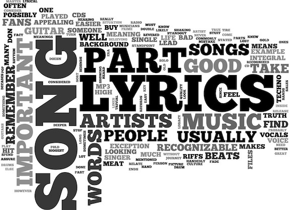

## *Summary*

Music can be the creature of the anges. The development of songs had proceeded steadily since different enviornment in different time peroids.

The whole dataset: “lyrics.csv” is a filtered corpus of 100,000+ song lyrics from MetroLyrics. Available features are song name, year, artist, genre, and lyrics. You can find the complete 380,000+ song lyrics data on Kaggle. A lyrics.RData file is also provided in the $'\data'$ folder.

### Envioenmental settings

This report is prepared with the following environmental settings.

```
##                _
## platform       x86_64-w64-mingw32
## arch           x86_64
## os             mingw32
## system         x86_64, mingw32
## status
## major          3
## minor          6.1
## year           2019
## month          07
## day            05
## svn rev        76782
## language       R
## version.string R version 3.6.1 (2019-07-05)
## nickname       Action of the Toes
```

First,I process the raw textual data ‘lyrics.csv’ saved in $ data $ file by cleaning data, removing stopwords and creating a tidy version of texts which is saved in $ output $ file for this report.

## *Genre of songs in different time*: Different time peroids influence Genre of Music?

From 1970 to 2019, Rock and Pop are the main thems of types of songs. Also, given any specific peroids (e.g 2000 - 2010), Rock(Top 1) and POP(Top2) are still the most popular music genre.

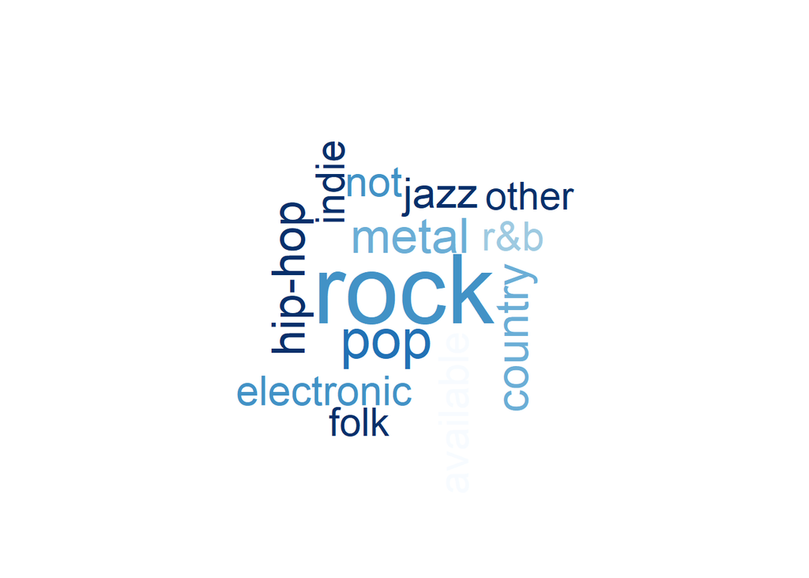

### Graphs of Top5 popular music Genre in five time peroids

From these graphs, we can see that Rock and POP always take the 1st and 2nd position of the songs’ genres.

During 1970-1990, Jazz was at the 3rd position. However, after 1990, proportion of Hiphop and Metal is increasing dramatically which means more and more people were accepting these trypes of music, and the proportion of jazz start decreasing.

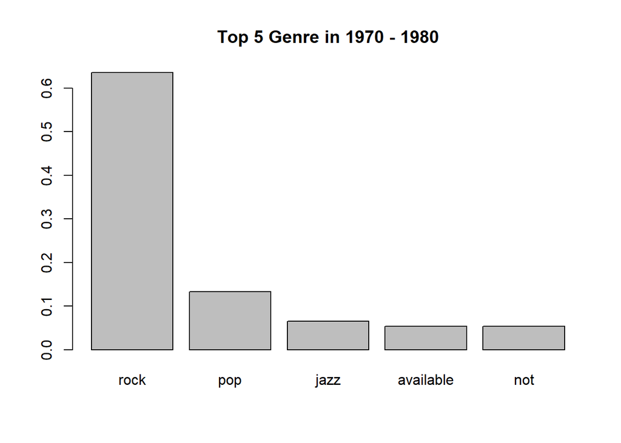

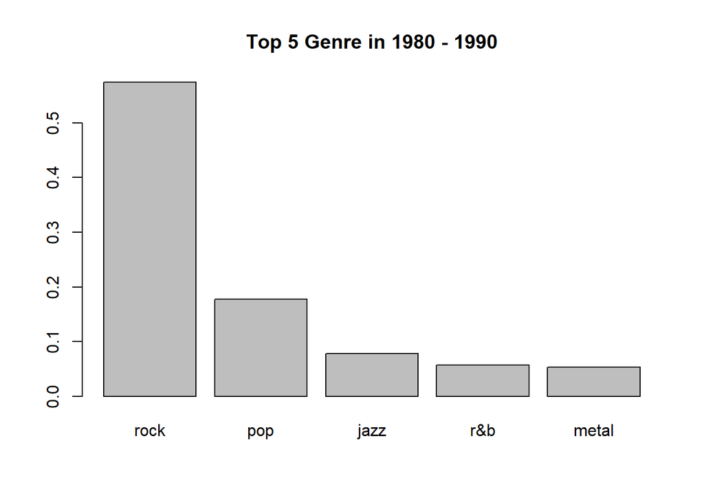

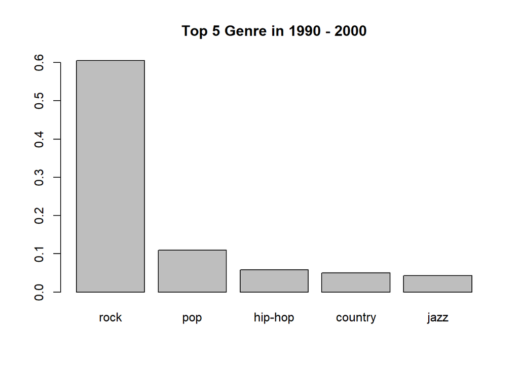

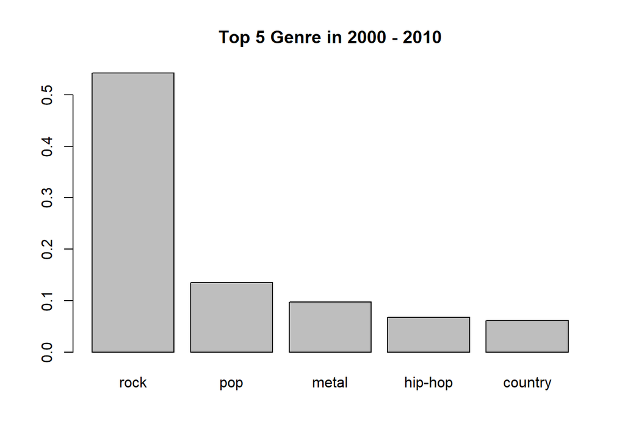

Jazz’s position decreases through time passes, and more and more Hippop and metal song appeared. Some reasons may explain this situation.

- 1, Young people prefer Metal and Hippop than Jazz because they think they are cooler than “classic” jazz, and jazz music should belong to their parents.
- 2, Different living pace in different time peroid can also decide people’s preference of music. Current life pace is much faster than before which means people do not have enough time to enjoy jazz, but need music like hiphop and metal to release their pressure.
- 3, Especially, in 2000-2010, hiphop and metal incresease dramatically. During 2000-2010, a lot of big events happened. 2000 internet bubble, 911, iraq war,2008 financial depression and so on happened in this peroid. Thus, I have a question that whether the Songs types have relationship with economics situations (e.g GDP, wars,depression)?

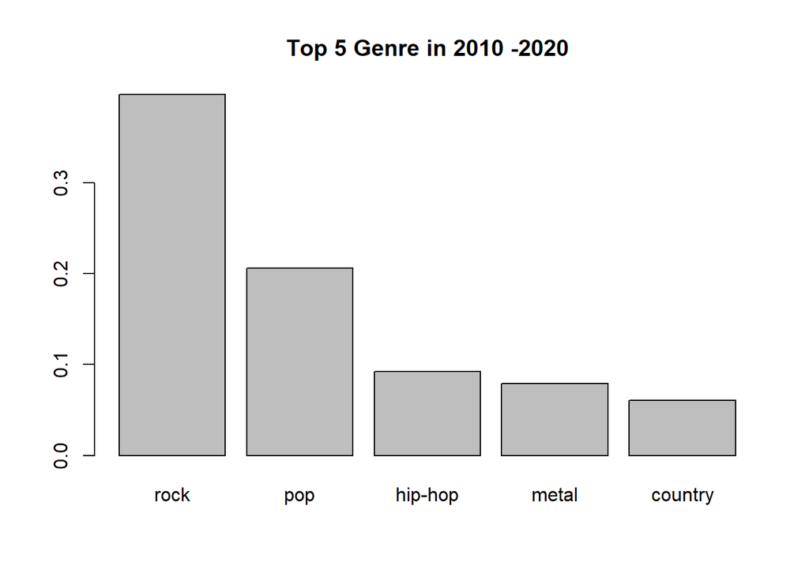

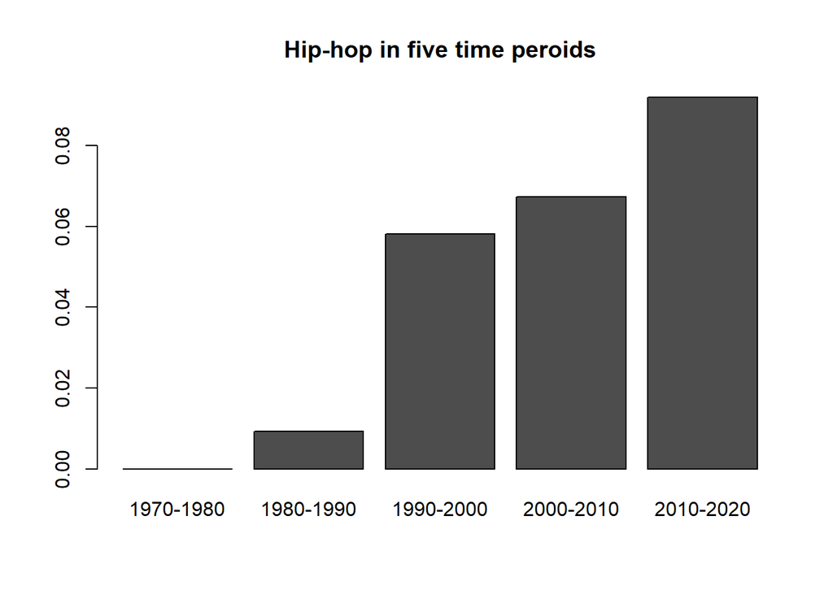

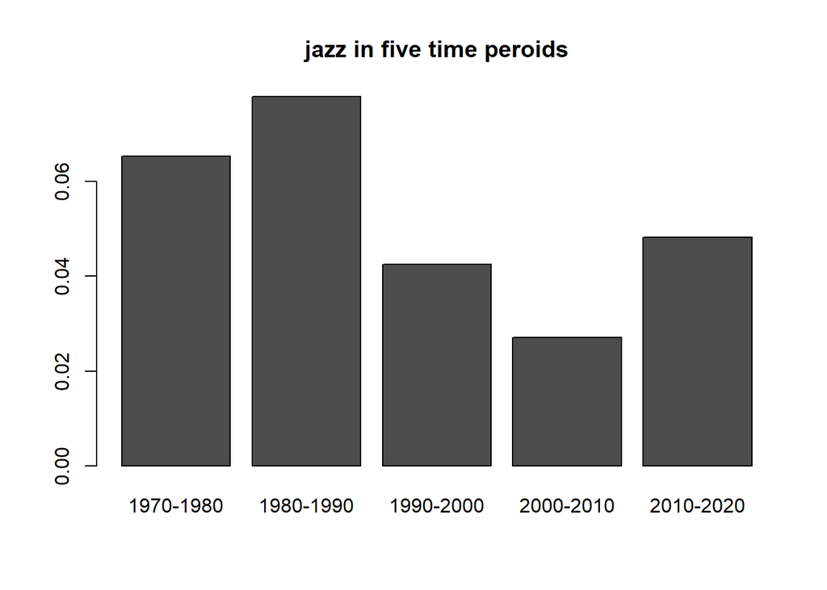

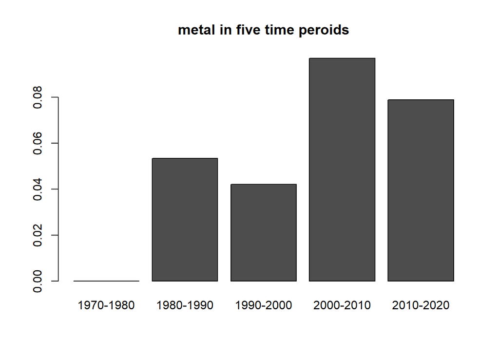

## *Sentiment of songs in different time*: Does Sentiment of songs have relationship with GDP Growth in different time peroid?

In previous part, I have a guess that whether a song can reflect economics situations (e.g GDP, wars,depression)? Here, I would use package $"sentimentr"$ to calculate the sentiment score of songs in five different peroid 1970-1980, 1980-1990,1990-2000,2000-2010,2010-2019, and compare these scores with avergae GDP Growth of these peroids. (GDP Growth data is collected form google, just 5 data points)

Sentimentr is designed to quickly calculate text polarity sentiment at the sentence level and optionally aggregate by rows or grouping variable(s). If the score is larger than 0, then it means that the songs’ lyrics is positive (happy, positive, good); if the score is less than 0, then it means that the songs’ lyrics is negative (sad, negative, bad). We will collect all lyrics of each time peroid, conbine them together, and calculate a sentiment score for each peorid.

As the graph shown below, we found that 1990-2000 and 2000-2010 are transition point that attitude of lyrics become negative from positive. In general, the lyrics become negative in 2000-2010, and this situation fits our assumption in previous section. Thus, I would compare Sentiment Score with GDP Growth to prove my guess.

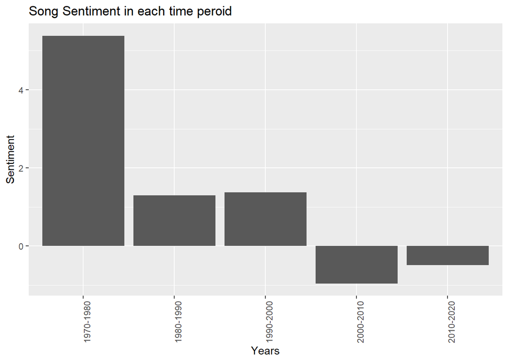

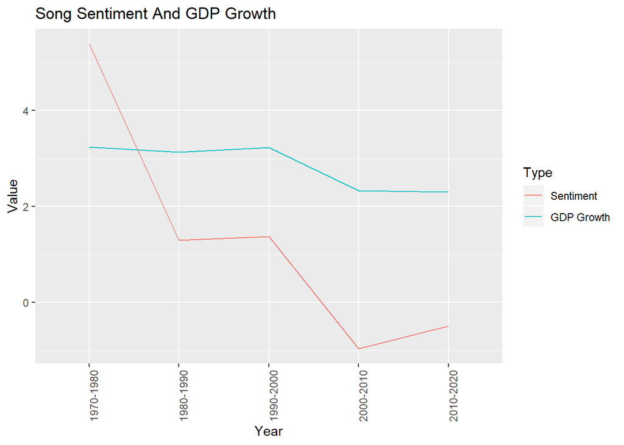

```
## The correlation between GDP_Growth and Song's Sentiment:  0.7762038
```

[figure not shown]